# Homework week 5 day 2

```r
library(tidyverse)
library(CodeClanData)
library(ggthemes)
```

```r
# Create colour scheme
col_scheme <- c("#E89FE9", "#50434F", "#B6A7B5", "#F9A472", "#BD7040")
```

# MVP

## 4.1 Part 1

### 1. Take the data in the dataset **qb_revenue_breakdown** and make a stacked bar chart showing the sources of revenue across the two years in the dataset.

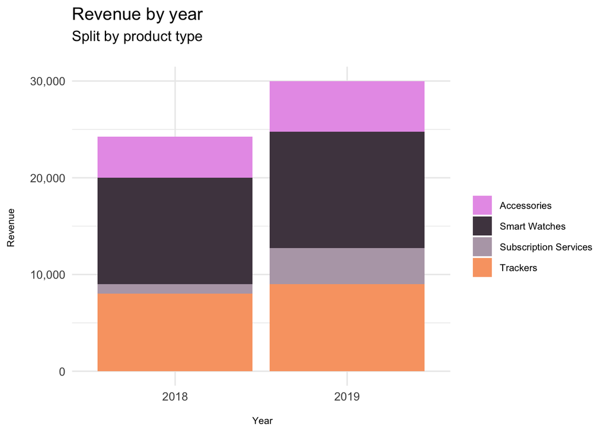

```r
ggplot(qb_revenue_breakdown) +
  aes(x = Year, y = Revenue, fill = Product) +
  geom_col() +
  scale_y_continuous(labels = scales::comma) +
  theme_minimal(base_size = 12) +
  theme(axis.title = element_text(size = 8)) +
  theme(legend.text = element_text(size = 8)) +
  scale_fill_manual(values = col_scheme) +
  labs(
    x = "\n Year",
    y = "Revenue \n",
    title = "Revenue by year",
    subtitle = "Split by product type \n",
    fill = ""
  )
```

### 2. Make a line chart showing monthly sales of the “flagship product” - the ‘KwikBit Unit 1’ - over the last year. This data is inside qb_monthly_sales, but you will need to use filter() or subset() (base R).

```r
qb_monthly_sales <-
  qb_monthly_sales
```

```r
qb_monthly_sales_flagship <-
  qb_monthly_sales %>%
  filter(Cashflow == "Kwikbit Unit 1 Sales")
```

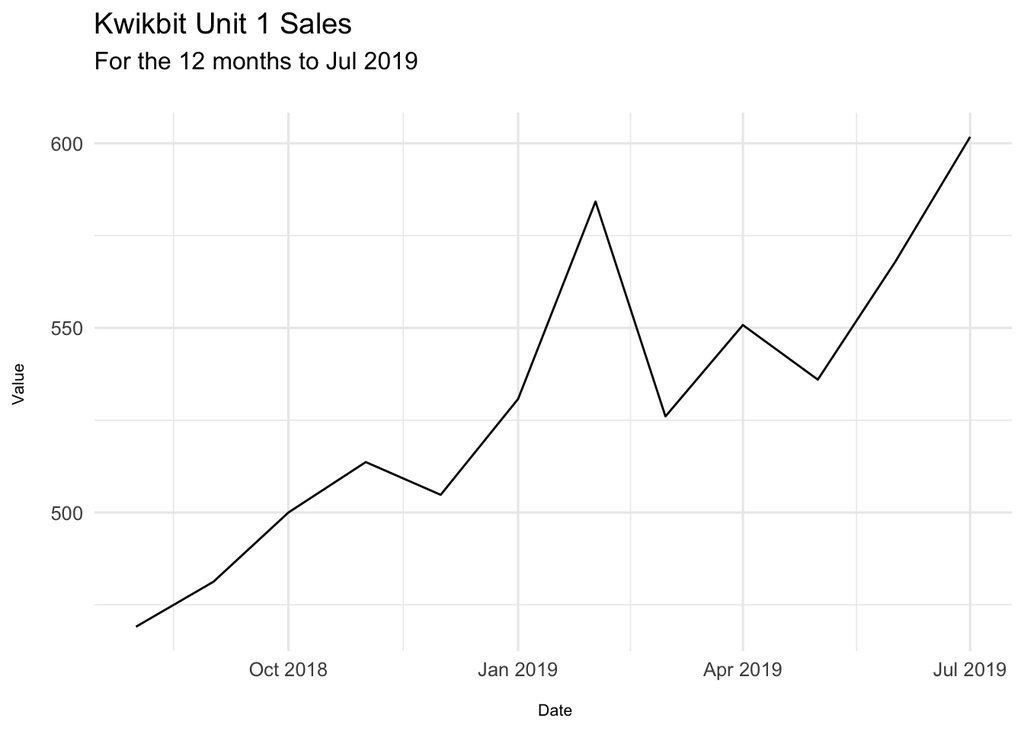

```r
ggplot(qb_monthly_sales_flagship) +
  aes(x = Date, y= Amount) +
  geom_line() +
  theme_minimal(base_size = 12) +
  theme(axis.title = element_text(size = 8)) +
  theme(legend.text = element_text(size = 8)) +
  scale_colour_manual(values = col_scheme) +
  labs(
    x = "\n Date",
    y = "Value \n",
    title = "Kwikbit Unit 1 Sales",
    subtitle = "For the 12 months to Jul 2019 \n"
  )
```

### 3. Make a line chart showing monthly revenue and costs over the last year. This data is also in qb_monthly_sales.

```r
qb_monthly_sales_costs_rev <-
  qb_monthly_sales %>%
  filter(Cashflow %in% c("Total Revenue", "Cost") )
```

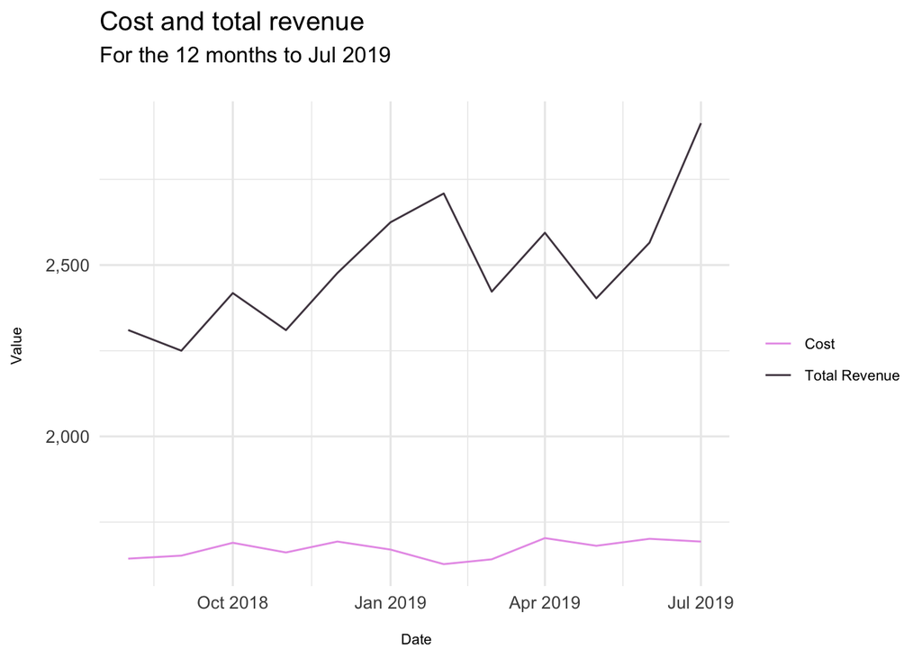

```r
ggplot(qb_monthly_sales_costs_rev) +
  aes(x = Date, y = Amount, colour = Cashflow) +
  geom_line() +
  scale_y_continuous(breaks = c(1000, 1500, 2000, 2500, 3000),  labels = scales::comma) +
  theme_minimal(base_size = 12) +
  theme(axis.title = element_text(size = 8)) +
  theme(legend.text = element_text(size = 8)) +
  scale_colour_manual(values = col_scheme) +
  labs(
    x = "\n Date",
    y = "Value \n",
    title = "Cost and total revenue",
    subtitle = "For the 12 months to Jul 2019 \n",
    colour = ""
  )
```

### 4.Show annual sales of personal fitness trackers over the last 5 years broken down by company as a ribbon plot (use geom_area). This data is in **qb_competitors**.

```r
qb_competitors <-
  qb_competitors
```

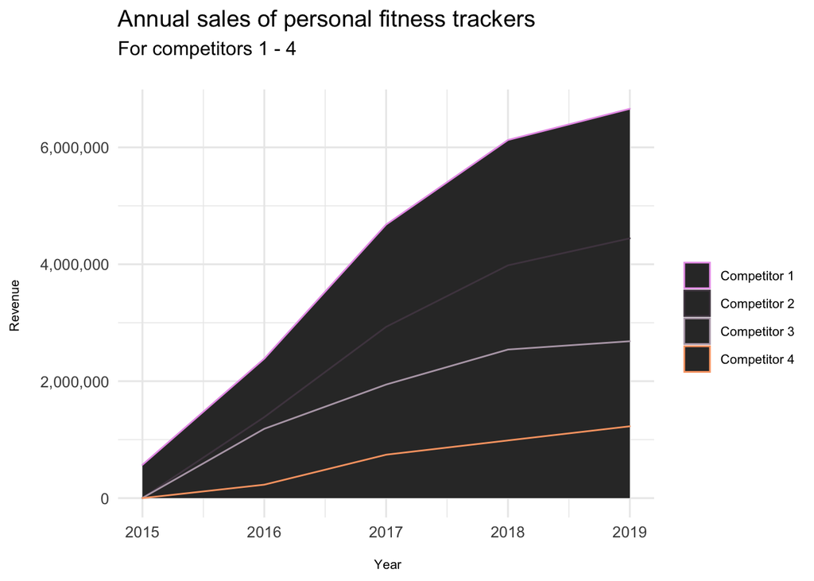

```r
ggplot(qb_competitors) +
  aes(x = Year, y =  Revenue, colour = Company) +
  scale_y_continuous(labels = scales::comma) +
  geom_area() +
  theme_minimal(base_size = 12) +
  theme(axis.title = element_text(size = 8)) +
  theme(legend.text = element_text(size = 8)) +
  scale_colour_manual(values = col_scheme) +
   labs(
    x = "\n Year",
    y = "Revenue \n",
    title = "Annual sales of personal fitness trackers",
    subtitle = "For competitors 1 - 4 \n",
    colour = ""
   )
```

### 5. Now show the sales from the four competitors as a line graph. Include an extra layer that shows the data points used to make the lines.

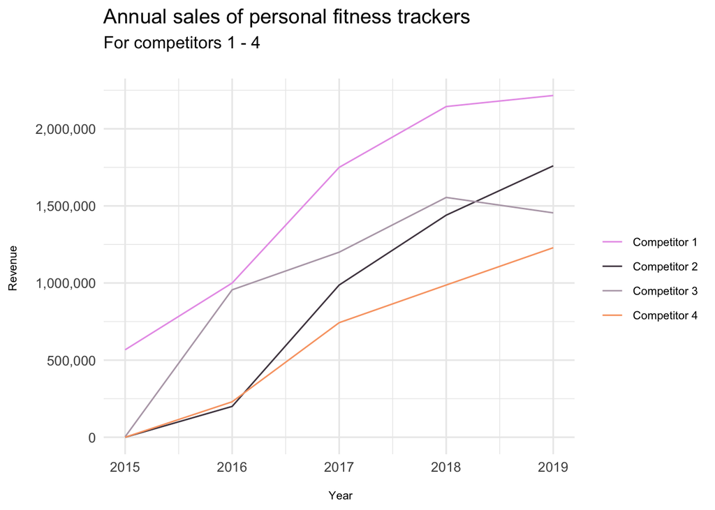

```r
ggplot(qb_competitors) +
  aes(x = Year, y =  Revenue, colour = Company) +
  geom_line() +
  scale_y_continuous(labels = scales::comma) +
  theme_minimal(base_size = 12) +
  theme(axis.title = element_text(size = 8)) +
  theme(legend.text = element_text(size = 8)) +
  scale_colour_manual(values = col_scheme) +
  labs(
    x = "\n Year",
    y = "Revenue \n",
    title = "Annual sales of personal fitness trackers",
    subtitle = "For competitors 1 - 4 \n",
    colour = ""
   )
```

### 6. Now the company wants to compare the number of steps that their device counts vs. their competitors. Make a line graph of the number of steps throughout time, and use faceting to compare between companies and people. The data for this is in **qb_device_data**.

- Not sure how to plot the time component of this
- ?what is the data showing - is this from a person wearing all the devices for 24 hours?
- Am adding a numeric “time”, showing minutes as a decimal of hours, to have a look, tho I think this is unnecessary and over-complicated! Not sure how to make a combined field in HH:MM format.
- I’ve used a free y scale here just to keep things visible; this is misleading - although the graphs for different products have similar shapes, when you look at the scale, the number of steps recorded has some large variances
- This graph is way too busy - is there a way to add a filter button so you can choose to show one person at a time?

```r
qb_device_data_with_time <- qb_device_data %>%
  mutate(mins_numeric = mins/60) %>%
  mutate(time = hours + mins_numeric)
```

```r
qb_device_data_with_time %>%
  arrange(desc(counts)) %>%
  head(100)
```

|  | device | id | hours | mins | counts | mins_numeric | time |
| --- | --- | --- | --- | --- | --- | --- | --- |
| 1 | competitor3 | person5 | 12 | 14 | 10525 | 0.23333333 | 12.233333 |
| 2 | qikbit1 | person5 | 12 | 14 | 9690 | 0.23333333 | 12.233333 |
| 3 | competitor1 | person5 | 12 | 14 | 9200 | 0.23333333 | 12.233333 |
| 4 | competitor3 | person2 | 6 | 27 | 8781 | 0.45000000 | 6.450000 |
| 5 | qikbit1 | person2 | 6 | 27 | 8196 | 0.45000000 | 6.450000 |
| 6 | competitor1 | person2 | 6 | 27 | 7032 | 0.45000000 | 6.450000 |
| 7 | competitor2 | person2 | 6 | 27 | 6581 | 0.45000000 | 6.450000 |
| 8 | competitor2 | person2 | 6 | 28 | 6133 | 0.46666667 | 6.466667 |
| 9 | competitor2 | person5 | 12 | 19 | 5910 | 0.31666667 | 12.316667 |
| 10 | competitor3 | person2 | 6 | 29 | 5423 | 0.48333333 | 6.483333 |

[output cut: 90 more lines]

### 1st attempt

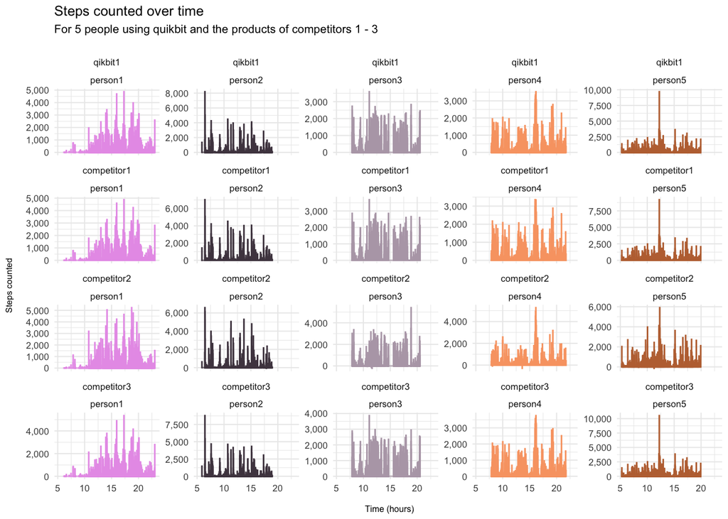

```r
ggplot(qb_device_data_with_time) +
  aes(x = time, y  = counts, colour = id, ) +
  geom_col(show.legend = FALSE) +
  #ylim(0,3000) +
  scale_y_continuous(labels = scales::comma) +
  theme_minimal(base_size = 8) +
  theme(axis.title = element_text(size = 6)) +
  theme(legend.text = element_text(size = 6)) +
  scale_colour_manual(values = col_scheme ) +
  facet_wrap(device ~ id, scales = "free_y") +
  labs(
    x = "\n Time (hours)",
    y = "Steps counted \n",
    title = "Steps counted over time",
    subtitle = "For 5 people using quikbit and the products of competitors 1 - 3 \n"
   )
```

### 2nd attempt: see what it looks like with only one person at a time

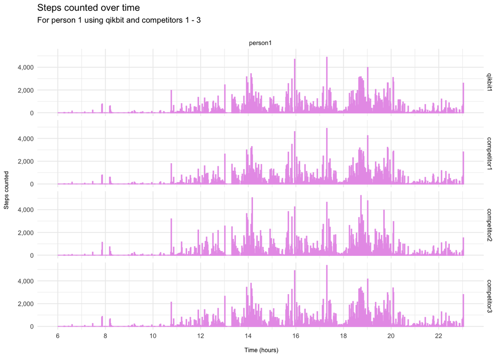

```r
qb_device_data_comp1 <- qb_device_data %>%
  #filter(Cashflow %in% c("qikbit1", "competitor1") ) %>%
  filter(id == "person1") %>%
  mutate(mins_numeric = mins/60) %>%
  mutate(time = hours + mins_numeric)

ggplot(qb_device_data_comp1) +
  aes(x = time, y  = counts, colour = id, ) +
  geom_col(show.legend = FALSE) +
  scale_x_continuous(breaks = c(2,4,6,8,10,12,14,16,18,20,22,24)) +
  scale_y_continuous(labels = scales::comma) +
  theme_minimal(base_size = 8) +
  theme(axis.title = element_text(size = 6)) +
  theme(legend.text = element_text(size = 6)) +
  scale_colour_manual(values = col_scheme ) +
  facet_grid(device ~ id) +
  labs(
    x = "\n Time (hours)",
    y = "Steps counted \n",
    title = "Steps counted over time",
    subtitle = "For person 1 using qikbit and competitors 1 - 3 \n"
   )
```

### 3rd attempt: just use hours, not minutes:

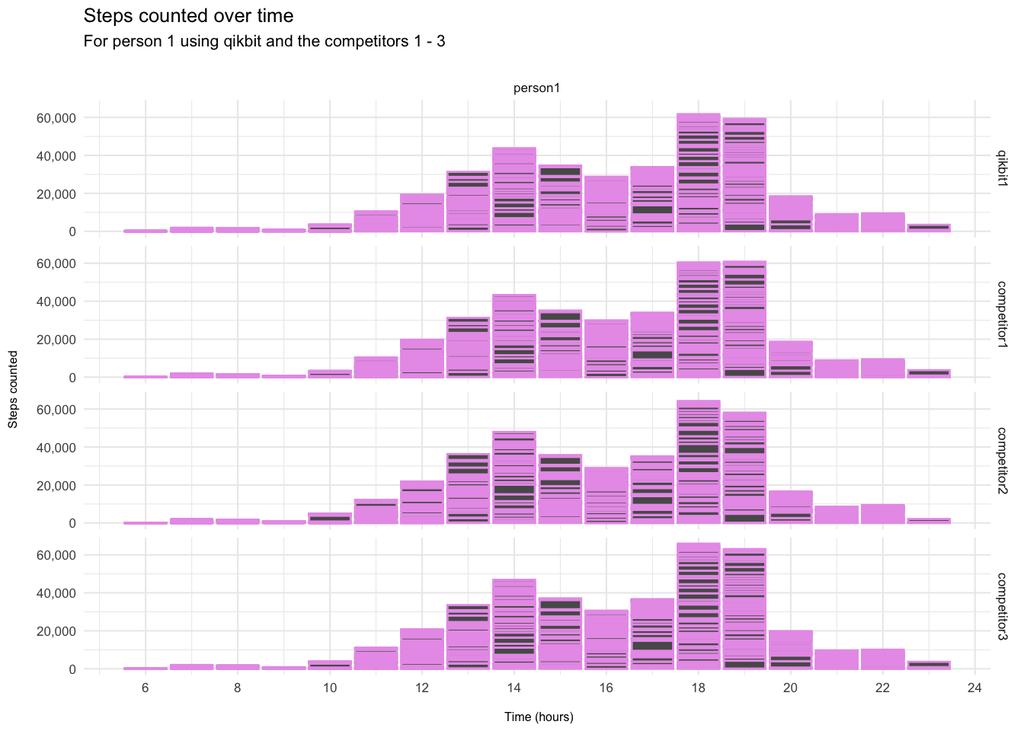

```r
qb_device_data_comp1 <- qb_device_data %>%
  #filter(Cashflow %in% c("qikbit1", "competitor1") ) %>%
  filter(id == "person1") %>%
  mutate(mins_numeric = mins/60) %>%
  mutate(time = hours + mins_numeric)

ggplot(qb_device_data_comp1) +
  aes(x = hours, y  = counts, colour = id) +
  geom_col(show.legend = FALSE) +
  scale_x_continuous(breaks = c(2,4,6,8,10,12,14,16,18,20,22,24)) +
  scale_y_continuous(labels = scales::comma) +
  theme_minimal(base_size = 8) +
  theme(axis.title = element_text(size = 6)) +
  theme(legend.text = element_text(size = 6)) +
  scale_colour_manual(values = col_scheme ) +
  facet_grid(device ~ id) +
  labs(
    x = "\n Time (hours)",
    y = "Steps counted \n",
    title = "Steps counted over time",
    subtitle = "For person 1 using qikbit and the competitors 1 - 3 \n"
   )
```